# 6. Dynamic Programming I

6. Dynamic Programming I

WU Xiaokun 吴晓堃

xkun.wu [at] gmail

2021/11/05

## Algorithmic paradigms

**Greedy**. Process the input in some order, *myopically* making *irrevocable* decisions.

- possibly, *no* natural greedy algorithm works.

**Divide-and-conquer**. Break up a problem into *independent* sub-problems; solve each subproblem; combine solutions to sub-problems to form solution to original problem.

- Not strong enough: reduce polynomial to faster running time.

**Dynamic programming**. Break up a problem into a series of *overlapping* sub-problems; combine solutions to smaller sub-problems to form solution to large subproblem.

- opposite of greedy: work through all possible global optimal.
  - explores exponentially large space, but not examining explicitly.

# Weighted Interval Scheduling

## Weighted Interval Scheduling Problem

Consider $n$ subjects are sharing a *single* resources.

- job $j$: start at $s_j$ and finish at $f_j$
  - has *weight/value* $w_j > 0$
- two jobs are **compatible** if they do not overlap

**Goal**: find max-weight subset of mutually compatible jobs.

|  | 0 | 1 | 2 | 3 | 4 | 5 | 6 | 7 | 8 | 9 |
| --- | --- | --- | --- | --- | --- | --- | --- | --- | --- | --- |
| 9 | + | + | + | + | + | + | + |  |  |  |
| 1 | + | + | + | + |  |  |  |  |  |  |
| 1 |  |  |  |  |  |  | + | + | + | + |

## Earliest-finish-time-first algorithm

**Earliest-finish-time-first**.

- Consider jobs in ascending order of finish time $f_j$.
- Add job to subset if it is compatible with previously chosen jobs.

**Recall**. Greedy algorithm is correct if all weights are 1.

**Observation**. Greedy algorithm fails for weighted version.

- goal and progress measure are unrelated.
- previous greedy decisions are irrevocable.

|  | 0 | 1 | 2 | 3 | 4 | 5 | 6 | 7 | 8 | 9 |
| --- | --- | --- | --- | --- | --- | --- | --- | --- | --- | --- |
| 9 | + | + | + | + | + | + | + |  |  |  |
| 1 | + | + | + | + |  |  |  |  |  |  |
| 1 |  |  |  |  |  |  | + | + | + | + |

## EFTF extension

**Convention**. Jobs are in ascending order of finish time: $f_1 \le f_2 \le . . . \le f_n$.

**Def**. $p(j)$ = largest index $i < j$ such that job $i$ is compatible with $j$.

- $i$ is rightmost interval that ends before $j$ begins

|  | 0 | 1 | 2 | 3 | 4 | 5 | 6 | 7 | 8 | 9 | $p$ |
| --- | --- | --- | --- | --- | --- | --- | --- | --- | --- | --- | --- |
| 1 | + | + | + | + |  |  |  |  |  |  | 0 |
| 9 | + | + | + | + | + | + | + |  |  |  | 0 |
| 1 |  |  |  |  |  |  | + | + | + | + | 1 |

## Dynamic programming: binary choice

**Def**. $OPT(j)$ = max weight of any subset of mutually compatible jobs for subproblem consisting only of jobs $1, 2, ..., j$.

**Goal**. $OPT(n)$ = max weight of any subset of mutually compatible jobs.

**Case 1**. $OPT(j)$ does not select job $j$.

- Must be an optimal solution to problem consisting of remaining jobs $1, 2, ..., j – 1$.

**Case 2**. $OPT(j)$ selects job $j$.

- Collect profit $w_j$.
- Can’t use incompatible jobs $\{ p(j) + 1, p(j) + 2, ..., j – 1 \}$.
- Must include optimal solution to problem consisting of remaining compatible jobs $1, 2, ..., p(j)$.

## DP: binary choice (cont.)

**Def**. $OPT(j)$ = max weight of any subset of mutually compatible jobs for subproblem consisting only of jobs $1, 2, ..., j$.

**Goal**. $OPT(n)$ = max weight of any subset of mutually compatible jobs.

**Case 1**. $OPT(j)$ does not select job $j$.

**Case 2**. $OPT(j)$ selects job $j$.

**Bellman equation**.

$$OPT(n) = \left\{ \begin{array}{lcl}
0 & \text{if} & j = 0 \\
\max \{OPT(j-1), w_j + OPT(p(j))\} & \text{if} & j > 0 \\
\end{array}\right.$$

## Brute-force scheduling

`BRUTE-FORCE`($n, s_1, \ldots, s_n, f_1, \ldots, f_n, w_1, \ldots, w_n$)

1. SORT jobs by finish times and renumber so that $f_1 \le f_2 \le \ldots \le f_n$;
2. Compute $p[1], p[2], \ldots, p[n]$ via binary search;
3. RETURN `COMPUTE-OPT`($n$);

`COMPUTE-OPT`($j$)

1. IF ($j = 0$): RETURN 0;
2. ELSE:
   1. RETURN $\max$ { `COMPUTE-OPT`($j – 1$), $w_j$ + `COMPUTE-OPT`($p[j]$) };

## Quiz: brute-force scheduling

What is running time of `COMPUTE-OPT`(n) in the worst case?

**A**. $\Theta(n \log n)$  
**B**. $\Theta(n^2)$  
**C**. $\Theta(1.618^n)$  
**D**. $\Theta(2^n)$

`COMPUTE-OPT`($j$)

1. IF ($j = 0$): RETURN 0;
2. ELSE:
   1. RETURN $\max$ { `COMPUTE-OPT`($j – 1$), $w_j$ + `COMPUTE-OPT`($p[j]$) };

## Brute-force scheduling: analysis

**Observation**. Recursive algorithm is spectacularly slow because of overlapping sub-problems $\Rightarrow$ *exponential*-time algorithm.

**Ex**. # recursive calls for family of “layered” instances grows like Fibonacci sequence.

| 0 | 1 | 2 | 3 | 4 | 5 |
| --- | --- | --- | --- | --- | --- |
| + | + | + |  |  |  |
|  | + | + | + |  |  |
|  |  | + | + | + |  |
|  |  |  | + | + | + |

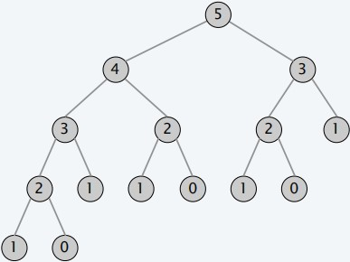

## Memoized scheduling

**Top-down dynamic programming (memoization)**.

- Cache result of subproblem $j$ in $M[j]$.
- Use $M[j]$ to avoid solving subproblem $j$ more than once.

`TOP-DOWN`($n, s_1, \ldots, s_n, f_1, \ldots, f_n, w_1, \ldots, w_n$)

1. SORT jobs by finish times and renumber so that $f_1 \le f_2 \le \ldots \le f_n$;
2. Compute $p[1], p[2], \ldots, p[n]$ via binary search;
3. $M[0] = 0$;
4. RETURN `M-COMPUTE-OPT`($n$);

`M-COMPUTE-OPT`($j$)

1. IF ($M[j]$ is uninitialized):
   1. $M[j] = \max$ { `M-COMPUTE-OPT`($j – 1$), $w_j$ + `M-COMPUTE-OPT`($p[j]$) };
2. RETURN $M[j]$;

## Memoized scheduling: analysis

**Claim**. Memoized version of algorithm takes $O(n \log n)$ time.  
**Pf**.

- Sort by finish time: $O(n \log n)$.
- Compute $p[j]$ for each $j$: $O(n \log n)$ via binary search.
- `M-COMPUTE-OPT`($j$): each invocation takes $O(1)$ time and either
  - 1. returns an initialized value $M[j]$
  - 2. initializes $M[j]$ and makes two recursive calls
- Progress measure $\Phi$ = # initialized entries among $M[1..n]$.
  - initially $\Phi = 0$; throughout $\Phi \le n$.
  - 2. increases $\Phi$ by 1 $\Rightarrow \le 2n$ recursive calls.
- Overall running time of `M-COMPUTE-OPT`($n$) is $O(n)$.

## Memoized scheduling: find a solution

**Q**. DP algorithm computes optimal value. How to find optimal solution?  
**A**. Make a second pass by calling `FIND-SOLUTION`($n$).

`FIND-SOLUTION`($j$)

1. IF ($j = 0$): RETURN $\emptyset$;
2. ELSE IF ($w_j + M[p[j]] > M[j – 1]$):
   1. RETURN $\{j\} \cup$ `FIND-SOLUTION`($p[j]$);
3. ELSE:
   1. RETURN `FIND-SOLUTION`($j – 1$);

## Bottom-up DP

**Bottom-up dynamic programming**. Unwind recursion.

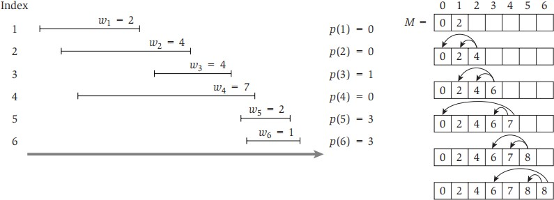

## Bottom-up DP: algorithm

`BOTTOM-UP`($n, s_1, \ldots, s_n, f_1, \ldots, f_n, w_1, \ldots, w_n$)

1. SORT jobs by finish times and renumber so that $f_1 \le f_2 \le \ldots \le f_n$;
2. Compute $p[1], p[2], \ldots, p[n]$ via binary search;
3. $M[0] = 0$;
4. FOR $j = 1 .. n$:
   1. $M[j] = \max \{ M[j – 1], w_j + M[p[j]] \}$;

**Running time**. The bottom-up version takes $O(n \log n)$ time.

## Maximum Sub-array Problem

**Goal**. Given an array $x$ of n integer (positive or negative), find a contiguous sub-array whose sum is maximum.

**Ex**.

| sum | 12 | 5 | −1 | 31 | −61 | 59 | 26 | −53 | 58 | 97 | −93 | −23 | 84 | −15 | 6 |
| --- | --- | --- | --- | --- | --- | --- | --- | --- | --- | --- | --- | --- | --- | --- | --- |
| 187 |  |  |  |  |  | + | + | + | + | + |  |  |  |  |  |

**Applications**. Computer vision, data mining, genomic sequence analysis, technical job interviews, etc.

## Maximum Sub-array: brute-force

**Goal**. Given an array $x$ of n integer (positive or negative), find a contiguous sub-array whose sum is maximum.

**Ex**.

| sum | 12 | 5 | −1 | 31 | −61 | 59 | 26 | −53 | 58 | 97 | −93 | −23 | 84 | −15 | 6 |
| --- | --- | --- | --- | --- | --- | --- | --- | --- | --- | --- | --- | --- | --- | --- | --- |
| 187 |  |  |  |  |  | + | + | + | + | + |  |  |  |  |  |

**Brute-force algorithm**.

- For each $i$ and $j$ : computer $a[i] + a[i+1] + \ldots + a[j]$.
- Takes $\Theta(n^3)$ time.

**Apply “cumulative sum” trick**.

- Pre-compute cumulative sums: $S[i] = a[0] + a[1] + \ldots + a[i]$.
- Now $a[i] + a[i+1] + \ldots + a[j] = S[j] − S[i−1]$.
- Improves running time $\Theta(n^2)$.

## Kadane’s algorithm

**Def**. $OPT(i)$ = max sum of any sub-array of $x$ whose rightmost index is $i$.

**Goal**. $\max_i OPT(i)$

**Bellman equation**.

$$OPT(i) = \left\{ \begin{array}{lcl}
x_1 & \text{if} & i = 1 \\
\max \{x_i, x_i + OPT(i-1)\} & \text{if} & i > 1 \\
\end{array}\right.$$

**Running time**. $O(n)$.

## Maximum Rectangle Problem

**Goal**. Given an $n$-by-$n$ matrix $A$, find a rectangle whose sum is maximum.

|  |  |  | + | + | + |  |  |
| --- | --- | --- | --- | --- | --- | --- | --- |
|  | −2 | 5 | 0 | −5 | −2 | 2 | −3 |
| + | 4 | -3 | -1 | 3 | 2 | 1 | −1 |
| + | −5 | 6 | 3 | −5 | −1 | -4 | −2 |
| + | −1 | -1 | 3 | −1 | 4 | 1 | 1 |
| + | 3 | -3 | 2 | 0 | 3 | -3 | −2 |
| + | −2 | 1 | -2 | 1 | 1 | 3 | −1 |
| + | 2 | -4 | 0 | 1 | 0 | -3 | −1 |

**Applications**. Databases, image processing, maximum likelihood estimation, technical job interviews, etc.

## Bentley’s algorithm

**Assumption**. Suppose you knew the left and right column indices $j$ and $jʹ$.

|  |  | $j$ |  | $j'$ |  |  |
| --- | --- | --- | --- | --- | --- | --- |
| −2 | 5 | 0 | −5 | −2 | 2 | −3 |
| 4 | -3 | -1 | 3 | 2 | 1 | −1 |
| −5 | 6 | 3 | −5 | −1 | -4 | −2 |
| −1 | -1 | 3 | −1 | 4 | 1 | 1 |
| 3 | -3 | 2 | 0 | 3 | -3 | −2 |
| −2 | 1 | -2 | 1 | 1 | 3 | −1 |
| 2 | -4 | 0 | 1 | 0 | -3 | −1 |

| $x$ |
| --- |
| −7 |
| 4 |
| −3 |
| 6 |
| 5 |
| 0 |
| 1 |

## Bentley’s algorithm (cont.)

**An $O(n^3)$ algorithm**.

1. Pre-compute cumulative row sums: $\sum_{k=1}^j A_{ik}$;
2. For each $j < jʹ$:
   1. define array $x$ using row-sum differences: $x_i = S_{ij'} - S_{ij}$;
   2. run Kadane’s algorithm in array $x$;

**Open problem**. $O(n^{3−\epsilon})$ for any constant $\epsilon > 0$.

# Segmented least squares

## Least squares

**Least squares**. Foundational problem in statistics.

- Given $n$ points in the plane: $(x_1, y_1), (x_2, y_2) , \ldots, (x_n, y_n)$.
- Find a line $y = ax + b$ that minimizes the sum of the squared error:

$$SSE = \sum_{i=1}^n (y_i - ax_i - b)^2$$

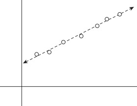

## Segmented Least Squares Problem

**Segmented least squares**.

- Points lie roughly on a sequence of line segments.
- Given $n$ points in the plane: $(x_1, y_1), (x_2, y_2) , \ldots, (x_n, y_n)$ with $x_1 < x_2 < ... < x_n$, find a *sequence of lines* that minimizes $f(x)$.

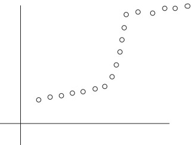

**Q**. What is a reasonable choice for $f(x)$ to balance *accuracy* and *parsimony*?

- goodness of fit vs. number of lines

**Goal**. Minimize $f(x) = E + c L$ for some constant $c > 0$, where

- $E$ = sum of SSEs in each segment.
- $L$ = number of lines.

## Dynamic programming: multi-way choice

**Notation**.

- $OPT(j)$ = minimum cost for points $p_1, p_2, \ldots, p_j$.
- $e_{ij}$ = SSE for for points $p_i, p_{i+1}, \ldots, p_j$.

**To compute $OPT(j)$**:

- Last segment uses points $p_i, p_{i+1}, \ldots, p_j$ for some $i \le j$.
- Cost = $e_{ij} + c + OPT(i – 1)$.

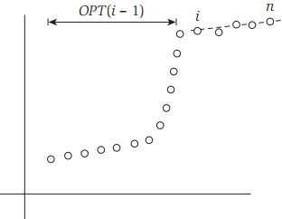

**Bellman equation**.

$$OPT(j) = \left\{ \begin{array}{lcl}
0 & \text{if} & j = 0 \\
\min_{1 \le i \le j} \{e_{ij} + c + OPT(i-1)\} & \text{if} & j
> 0 \\
\end{array}\right.$$

## Segmented Least Squares: algorithm

`SEGMENTED-LEAST-SQUARES`($n, p_1, \ldots, p_n, c$)

1. FOR $j = 1 .. n$:
   1. FOR $i = 1 .. j$:
      1. Compute the SSE $e_{ij}$ for the points $p_i, p_{i+1}, \ldots, p_j$;
2. $M[0] = 0$;
3. FOR $j = 1 .. n$:
   1. $M[j] = \min_{1 \le i \le j} \{e_{ij} + c + M[i-1]\}$;
4. RETURN $M[n]$;

## Segmented Least Squares: analysis

**Theorem**. [Bellman 1961] DP algorithm solves the segmented least squares problem in $O(n^3)$ time and $O(n^2)$ space.  
**Pf**.

- Bottleneck = computing SSE $e_{ij}$ for each $i$ and $j$.

$$a_{ij} = \frac{
n \sum_k x_k y_k - (\sum_k x_k)(\sum_k y_k)
}{
n \sum_k x_k^2 - (\sum_k x_k)^2
},
b_{ij} = \frac{
\sum_k y_k - a_{ij} \sum_k x_k
}{n}$$

- $O(n)$ to compute $e_{ij}$.

**Remark**. Can be improved to $O(n^2)$ time.

- For each $i$: pre-compute cumulative sums: $\sum_k x_k, \sum_k y_k, \sum_k x_k^2, \sum_k x_k y_k$
- Using cumulative sums, can compute $e_{ij}$ in $O(1)$ time.

# Knapsack problem

## Knapsack problem

**Goal**. Pack knapsack so as to maximize total value of items taken.

- There are $n$ items: item $i$ provides value $v_i > 0$ and weighs $w_i > 0$.
- Value of a subset of items = sum of values of individual items.
- Knapsack has weight limit of $W$.

**Assumption**. All values and weights are integral.

**Ex**. The subset { 1, 2, 5 } has value $35 (and weight 10).

**Ex**. The subset { 3, 4 } has value $40 (and weight 11).

| $i$ | 1 | 2 | 3 | 4 | 5 |
| --- | --- | --- | --- | --- | --- |
| $v_i$ | 1 | 6 | 18 | 22 | 28 |
| $w_i$ | 1 | 2 | 5 | 6 | 7 |

weight limit $W = 11$

## Quiz: Knapsack via greedy

Which algorithm solves knapsack problem?

**A**. Greedy-by-value: repeatedly add item with maximum $v_i$.  
**B**. Greedy-by-weight: repeatedly add item with minimum $w_i$.  
**C**. Greedy-by-ratio: repeatedly add item with maximum ratio $v_i / v_i$.  
**D**. None of the above.

| $i$ | 1 | 2 | 3 | 4 | 5 |
| --- | --- | --- | --- | --- | --- |
| $v_i$ | 1 | 6 | 18 | 22 | 28 |
| $w_i$ | 1 | 2 | 5 | 6 | 7 |

weight limit $W = 11$

## Quiz: Knapsack via DP

Which sub-problems?

**A**. $OPT(w)$ = optimal value of knapsack problem with weight limit w.  
**B**. $OPT(i)$ = optimal value of knapsack problem with items $1, \ldots, i$.  
**C**. $OPT(i, w)$ = optimal value of knapsack problem with items $1, \ldots, i$ subject to weight limit $W$.  
**D**. Any of the above.

A/B: not eliminating any conflict, thus reduce to brute-force.

## Dynamic programming: two variables

**Def**. $OPT(i, w)$ = optimal value of knapsack problem with items $1, \ldots, i$, subject to weight limit $w$.

**Goal**. $OPT(n, W)$.

**Case 1**. $OPT(i, w)$ does not select item $i$.

- $OPT(i, w)$ selects best of $\{ 1, 2, \ldots, i – 1 \}$ subject to weight limit $w$.

**Case 2**. $OPT(i, w)$ selects item $i$.

- Collect value $v_i$.
- New weight limit = $w – w_i$.
- $OPT(i, w)$ selects best of $\{ 1, 2, \ldots, i – 1 \}$ subject to new weight limit.

## DP: two variables (cont.)

**Def**. $OPT(i, w)$ = optimal value of knapsack problem with items $1, \ldots, i$, subject to weight limit $w$.

**Goal**. $OPT(n, W)$.

**Case 1**. $OPT(i, w)$ does not select item $i$.

**Case 2**. $OPT(i, w)$ selects item $i$.

**Bellman equation**.

$$OPT(i, w) = \left\{ \begin{array}{ll}
0 & \text{if}\ i = 0 \\
OPT(i-1, w) & \text{if}\ w_i > w \\
\max \{ OPT(i-1, w), v_i + OPT(i-1, w-w_i) \} & \text{otherwise} \\
\end{array}\right.$$

## DP: two-dimensional table

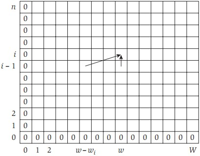

$$OPT(i, w) = \left\{ \begin{array}{ll}
0 & \text{if}\ i = 0 \\
OPT(i-1, w) & \text{if}\ w_i > w \\
\max \{ OPT(i-1, w), v_i + OPT(i-1, w-w_i) \} & \text{otherwise} \\
\end{array}\right.$$

## Knapsack problem: bottom-up DP

`KNAPSACK`($n, W, w_1, \ldots, w_n, v_1, \ldots, v_n$)

1. FOR $w = 0 .. W$: $M[0, w] = 0$;
2. FOR $i = 1 .. n$:
   1. FOR $w = 0 .. W$:
      1. IF ($w_i > w$): $M[i, w] = M[i – 1, w]$;
      2. ELSE: $M[i, w] = \max \{ M[i – 1, w], v_i + M[i – 1, w – w_i] \}$;
3. RETURN $M[n, W]$;

$$OPT(i, w) = \left\{ \begin{array}{ll}
0 & \text{if}\ i = 0 \\
OPT(i-1, w) & \text{if}\ w_i > w \\
\max \{ OPT(i-1, w), v_i + OPT(i-1, w-w_i) \} & \text{otherwise} \\
\end{array}\right.$$

## Knapsack problem: bottom-up DP demo

Knapsack size $W = 6$, items $w_1 = 2, w_2 = 2, w_3 = 3$.

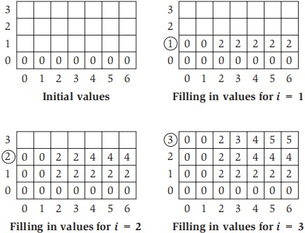

$$OPT(i, w) = \left\{ \begin{array}{ll}
0 & \text{if}\ i = 0 \\
OPT(i-1, w) & \text{if}\ w_i > w \\
\max \{ OPT(i-1, w), v_i + OPT(i-1, w-w_i) \} & \text{otherwise} \\
\end{array}\right.$$

## Knapsack problem: analysis

**Theorem**. The DP algorithm solves the knapsack problem with $n$ items and maximum weight W in $\Theta(n W)$ time and $\Theta(n W)$ space.  
**Pf**.

- Takes $O(1)$ time per table entry.
- There are $\Theta(n W)$ table entries.
- After computing optimal values, can trace back to find solution:
  - $OPT(i, w)$ takes item $i$ iff $M [i, w] > M [i – 1, w]$.

**Remarks**.

- Algorithm depends critically on assumption that weights are *integral*.
  - weights are integers between 1 and $W$

## Coin changing: revisit

**Problem**. Given $n$ coin denominations $\{ d_1, d_2, \ldots, d_n \}$ and a target value $V$, find the fewest coins needed to make change for $V$ (or report impossible).

**Recall**. Greedy cashier’s algorithm is optimal for U.S. coin denominations, but not for arbitrary coin denominations.

**Ex**. { 1, 10, 21, 34, 70, 100, 350, 1295, 1500 }.  
**Optimal**. 140¢ = 70 + 70.

## Coin changing: DP solution

**Def**. $OPT(v)$ = min number of coins to make change for $v$.

**Goal**. $OPT(V)$.

**Multiway choice**. To compute $OPT(v)$,

- Select a coin of denomination $c_i$ for some $i$.
- Select fewest coins to make change for $v – c_i$.

**Bellman equation**.

$$OPT(v) = \left\{ \begin{array}{ll}
\infty & \text{if}\ v < 0 \\
0 & \text{if}\ v = 0 \\
\min_{1 \le i \le n} \{ 1 + OPT(v-d_i) \} & \text{if}\ v > 0 \\
\end{array}\right.$$

**Running time**. $O(n V)$.

# RNA secondary structure

## RNA secondary structure

**RNA**. String $B = b_1 b_2 \ldots b_n$ over alphabet { A, C, G, U }.

**Secondary structure**. RNA is single-stranded so it tends to loop back and form *base pairs* with itself. This structure is essential for understanding behavior of molecule.

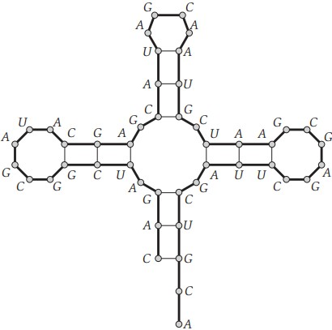

## RNA: matching rule

**Secondary structure**. A set of pairs $S = \{ (b_i, b_j) \}$ that satisfy:

- [Watson–Crick] $S$ is a matching and each pair in $S$ is a Watson–Crick complement: A–U, U–A, C–G, or G–C.
- [No sharp turns] The ends of each pair are separated by at least 4 intervening bases. If $(b_i, b_j) \in S$, then $i < j – 4$.
- [Non-crossing] If $(b_i, bj)$ and $(b_k, bl)$ are two pairs in $S$, then we cannot have $i < k < j < l$.

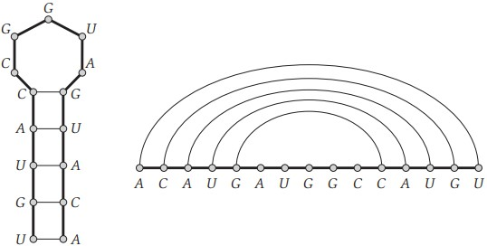

## RNA: hypothesis

**Secondary structure**. A set of pairs $S = \{ (b_i, b_j) \}$ that satisfy:

- [Watson–Crick] $S$ is a matching and each pair in $S$ is a Watson–Crick complement: A–U, U–A, C–G, or G–C.
- [No sharp turns] The ends of each pair are separated by at least 4 intervening bases. If $(b_i, b_j) \in S$, then $i < j – 4$.
- [Non-crossing] If $(b_i, bj)$ and $(b_k, bl)$ are two pairs in $S$, then we cannot have $i < k < j < l$.

**Free-energy hypothesis**. RNA molecule will form secondary structure with *minimum total free energy*.

- approximate by # base pairs: more base pairs $\Rightarrow$ lower free energy

**Goal**. Given an RNA molecule $B = b_1 b_2 \ldots b_n$, find a secondary structure $S$ that maximizes number of base pairs.

## Quiz: matching rule

**A**. Yes.  
**B**. No, violates Watson–Crick condition.  
**C**. No, violates no-sharp-turns condition.  
**D**. No, violates no-crossing condition.

## Quiz: RNA secondary structure

Which sub-problems?

**A**. $OPT(j)$ = max number of base pairs in secondary structure of the substring $b_1 b_2 \ldots b_j$.  
**B**. $OPT(j)$ = max number of base pairs in secondary structure of the substring $b_j b_{j+1} \ldots b_n$.  
**C**. Either A or B.  
**D**. Neither A nor B.

## RNA secondary structure: sub-problems

**First attempt**. $OPT(j)$ = max number of base pairs in secondary structure of the substring $b_1 b_2 \ldots b_j$.

**Goal**. $OPT(n)$.

**Choice**. Match bases $b_t$ and $b_j$.

**Difficulty**. Results in two sub-problems (but one of wrong form).

- Find secondary structure in $b_1 b_2 \ldots b_{t-1}$: $OPT(t-1)$.
- Find secondary structure in $b_{t+1} b_{t+2} \ldots b_{j-1}$.
  - break sub-structure: first base no longer $b_1$

## DP: intervals

**Def**. $OPT(i, j)$ = maximum number of base pairs in a secondary structure of the substring $b_i b_{i+1} \ldots b_j$.

**Case 1**. If $i \ge j – 4$.

- $OPT(i, j) = 0$ by no-sharp-turns condition.

**Case 2**. Base $b_j$ is not involved in a pair.

- $OPT(i, j) = OPT(i, j – 1)$.

**Case 3**. Base $b_j$ pairs with $b_t$ for some $i \le t < j – 4$.

- Non-crossing condition decouples resulting two sub-problems.
  - $OPT(i, j) = 1 + \max_t { OPT(i, t – 1) + OPT(t + 1, j – 1) }$.

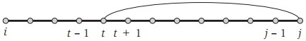

## Quiz: DP for RNA

In which order to compute $OPT(i, j)$?

**A**. Increasing $i$, then $j$.  
**B**. Increasing $j$, then $i$.  
**C**. Either **A** or **B**.  
**D**. Neither **A** nor **B**.

B

## Bottom-up DP over intervals

**Q**. In which order to solve the sub-problems?  
**A**. Do shortest intervals first—increasing order of $|j − i|$.

**Ex**. RNA sequence ACCGGUAGU.

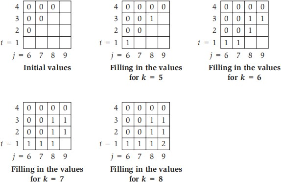

## DP for RNA: algorithm

`RNA-SECONDARY-STRUCTURE`($n, b_1, \ldots, b_n$)

1. FOR $k = 5 .. n – 1$:
   1. FOR $i = 1 .. n – k$:
      1. $j = i + k$;
      2. Compute $M[i, j]$ using formula;
2. RETURN $M[1, n]$;

**Theorem**. The DP algorithm solves the RNA secondary structure problem in $O(n^3)$ time and $O(n^2)$ space.

## Dynamic programming summary

**Outline**.

- Define a collection of (polynomial number of) sub-problems.
- Solution to original problem can be computed from sub-problems.
- Natural ordering of sub-problems from “smallest” to “largest” that enables determining a solution to a subproblem from solutions to smaller sub-problems.

**Techniques**.

- Binary choice: weighted interval scheduling.
- Multi-way choice: segmented least squares.
- Adding a new variable: knapsack problem.
- Intervals: RNA secondary structure.

**Top-down vs. bottom-up DP**. recursive vs. iterative.